# Практическое задание 8, модели 1 и 2

Баширова Карина

13 04 2020

# Пакеты

```r
library(DMwR) # SMOTE
library(DescTools)
library(caTools)
library(Matrix)
library(xgboost)
library(caret)
library(tidyverse)
library(randomForest)
library(plyr)
```

# Загрузка данных

```r
data <- readRDS("Practice_08_dataset.rds")


set.seed(726)
split <- sample.split(data$Target, SplitRatio = 0.7)

data$Target <- revalue(data$Target, c(">50K"=1))
data$Target <- revalue(data$Target, c("<=50K"=0))

train <- subset(data, split == TRUE)
test  <- subset(data, split == FALSE)

table(data$Target)
```

```
##
##     0     1
## 31880 11046
```

```r
data <- data %>%
  mutate(
    Target = factor(Target),
  )
```

# Модель 1

## Стандартная модель, случайный лес (Задание 1)

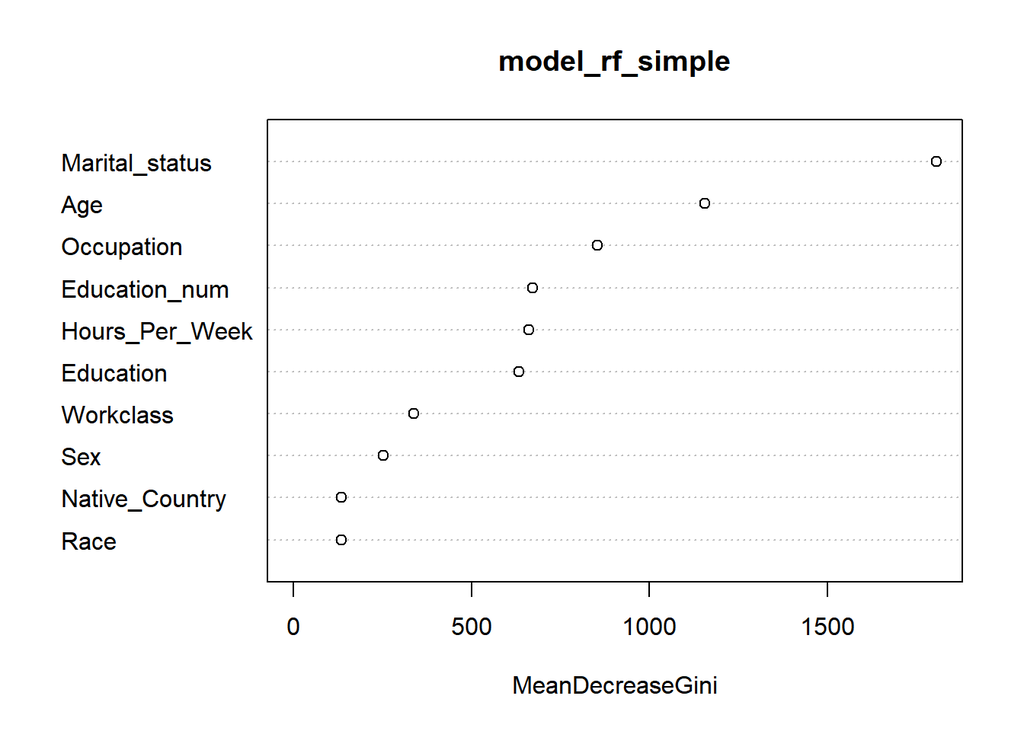

```r
# Модель
set.seed(1)
model_rf_simple <- randomForest(
  Target ~ .,
  data = train,
  ntree = 150, # кол-во деревьев
  mtry = 2)

varImpPlot(model_rf_simple)
```

```r
# Прогноз
test$prediction_rf_simple <- predict(model_rf_simple, test)

# Матрица сопряженности
confusionMatrix(data = test$prediction_rf_simple,
                reference = test$Target,
                positive = "1", mode = "everything")
```

```
## Confusion Matrix and Statistics
##
##           Reference
## Prediction    0    1
##          0 8767 1400
##          1  797 1914
##
##                Accuracy : 0.8294
##                  95% CI : (0.8228, 0.8359)
##     No Information Rate : 0.7427
##     P-Value [Acc > NIR] : < 2.2e-16
##
##                   Kappa : 0.5255
##
##  Mcnemar's Test P-Value : < 2.2e-16
##
##             Sensitivity : 0.5775
##             Specificity : 0.9167
##          Pos Pred Value : 0.7060
##          Neg Pred Value : 0.8623
##               Precision : 0.7060
##                  Recall : 0.5775
##                      F1 : 0.6354
##              Prevalence : 0.2573
##          Detection Rate : 0.1486
##    Detection Prevalence : 0.2105
##       Balanced Accuracy : 0.7471
##
##        'Positive' Class : 1
##
```

Наибольшее влияние на удовлетворенность доходом оказывает семейное положение и возраст.

# Модель 2

## Модель с сэмплированием (SMOTE), XGBoost (Задание 2)

```r
data <- readRDS("Practice_08_dataset.rds")

set.seed(726)
split <- sample.split(data$Target, SplitRatio = 0.7)
data$Target <- revalue(data$Target, c(">50K"=1))
data$Target <- revalue(data$Target, c("<=50K"=0))
train <- subset(data, split == TRUE)
test  <- subset(data, split == FALSE)
data <- data %>%
  mutate(
    Target = factor(Target),
  )
data <- as.data.frame(data)
test_xgb <- sparse.model.matrix(Target ~ . -1, data = test)
set.seed(313)

train_smote <- SMOTE(Target ~ ., data  = as.data.frame(data))
table(train_smote$Target)
```

```
##
##     0     1
## 44184 33138
```

```r
# Разряженная матрица
train_smote_xgb   <- sparse.model.matrix(Target ~ . -1, data = train_smote)
train_smote_label <- as.numeric(as.character(train_smote$Target))
```

Сэмплирование методом SMOTE привело к увеличению числа положительных результатов, но не довело соотношение положительных и отрицательных результатов до 50 на 50%.

```r
threshold <- 0.5
```

```r
set.seed(95)
model_xgb_smote <- xgboost(

  # Данные
  data = train_smote_xgb, label = train_smote_label,

  # Параметры модели
  max.depth = 5, colsample_bytree = 0.5, gamma = 0.2,
  eta = 0.1, nrounds = 35,

  # Тип задачи
  objective = "binary:logistic",

  verbose = 0)


test$predict_smote <- predict(model_xgb_smote, test_xgb)

test$predict_smote[test$predict_smote > threshold] <- 1
test$predict_smote[test$predict_smote <= threshold] <- 0
test$predict_smote <- as.factor(test$predict_smote)



confusionMatrix(data = test$predict_smote,
                reference = test$Target,
                positive = "1", mode = "everything")
```

```
## Confusion Matrix and Statistics
##
##           Reference
## Prediction    0    1
##          0 8767 1633
##          1  797 1681
##
##                Accuracy : 0.8113
##                  95% CI : (0.8044, 0.818)
##     No Information Rate : 0.7427
##     P-Value [Acc > NIR] : < 2.2e-16
##
##                   Kappa : 0.462
##
##  Mcnemar's Test P-Value : < 2.2e-16
##
##             Sensitivity : 0.5072
##             Specificity : 0.9167
##          Pos Pred Value : 0.6784
##          Neg Pred Value : 0.8430
##               Precision : 0.6784
##                  Recall : 0.5072
##                      F1 : 0.5805
##              Prevalence : 0.2573
##          Detection Rate : 0.1305
##    Detection Prevalence : 0.1924
##       Balanced Accuracy : 0.7120
##
##        'Positive' Class : 1
##
```

### Вывод по модели 3

Модель 3 приведена в отдельном файле.

В модели 3 с помощью сетки нашли оптимальные параметры mtry = 4, numRandomCuts = 3. (Я сократила количество проверяемых mtry и numRandomCuts до 2-х в связи с недостатком памяти и слишком долгим временем расчета на компьютере. Во время тестирования проверяла на сетке mtry = c(2,3,4), numRandomCuts = c(3,4), результаты были аналогичные).

Точность составила 79%. Каппа 0,45, Чувствительность 0,59, специфичность 0,85.

С помощью процедуры оверсэмплинга была проведена балансировка выборки. Таким образом, было увеличено количество измерений до 22316 для положительных/отрицательных ответов.

# Итоговый вывод

В ходе работы были построены следующие модели:

1. Модель без сэмплирования, алгоритм случайный лес
2. Модель с сэмплированием методом SMOTE, алгоритм XGBoost
3. Модель с сэмплированием методом оверсемплинга, алгоритм полностью случайный лес

Наилучшая чувствительность получилась у модели полностью случайного леса.

Во всех построенных моделях лучше всего определяется отрицательный ответ (<=50К).

По совокупности показателей наилучший результат у модели случайного леса.